## 1. Executive Summary

## 2. Experimental Design

## 3. Descriptive Statistical Analysis

Number of observations in treated set: 286

Number of observations in untreated set: 279

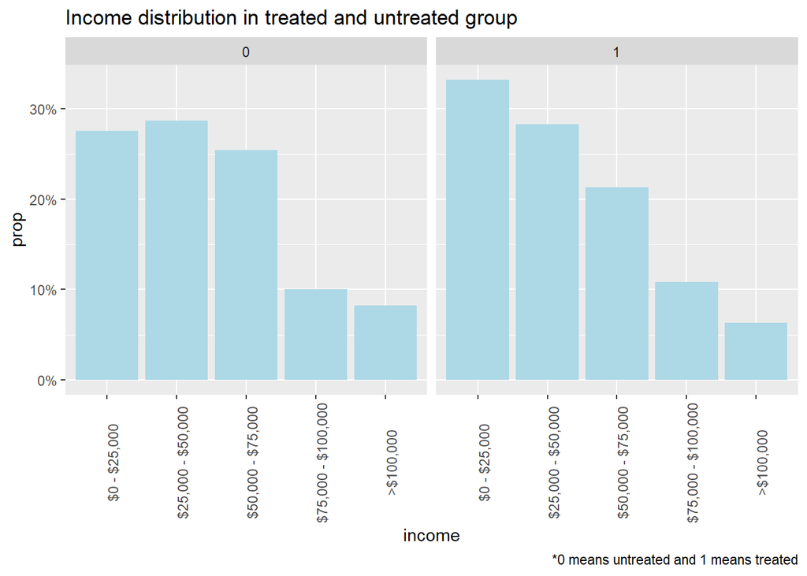

```r
# Income
ggplot(surveyData, aes(x = income, group = 1)) +
   geom_bar(aes(y = ..prop..), stat = 'count', fill = "lightblue") +
   scale_y_continuous(labels = scales::percent_format()) +
   facet_grid(~ treatment) +
   theme(axis.text.x = element_text(angle = 90)) +
   labs(title = "Income distribution in treated and untreated group",
        caption = "*0 means untreated and 1 means treated")
```

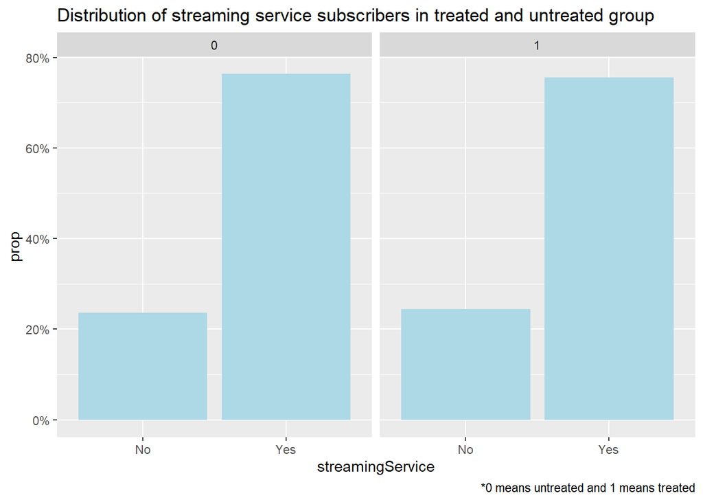

```r
# Streaming Service Subscribers
ggplot(surveyData, aes(x = streamingService, group = 1)) +
   geom_bar(aes(y = ..prop..), stat = 'count', fill = "lightblue") +
   scale_y_continuous(labels = scales::percent_format()) +
   facet_grid(~ treatment) +
   labs(title = "Distribution of streaming service subscribers in treated and untreated group",
        caption = "*0 means untreated and 1 means treated")
```

## 4. Causal Effect Analysis

```r
surveyData
```

[output not shown]

[output cut: 33 more lines]

We perform a T-test between the willingness to pay of the treatment and control groups. From the result, we can see that the mean response for the treatment group (table format) is lower than that for the control group (paragraph format) and the difference between the two means is statistically significant at the 0.001 significance level. We may infer that the table format of presenting the product significantly brings down the customers’ willingness to pay for the premium option than the paragraph format.

```r
t.test(surveyData$response_numeric ~ surveyData$treatment)
```

```
##
##  Welch Two Sample t-test
##
## data:  surveyData$response_numeric by surveyData$treatment
## t = 3.6365, df = 562.5, p-value = 0.0003017
## alternative hypothesis: true difference in means between group 0 and group 1 is not equal to 0
## 95 percent confidence interval:
##  0.1905973 0.6383122
## sample estimates:
## mean in group 0 mean in group 1
##        3.362007        2.947552
```

The box plot below demonstrates the distribution of the response (willingness to pay for the premium plan) from the control and treatment groups. We can see that most control group participants responded with a relatively positive answer, with most of them selecting 3 (somewhat likely) or higher; on the contrary, the treatment group participants responded with a relatively calm answer, while 50% (median) of the customers selected “likely” of different extent, a significant number of them in the treatment group selected “unlikely” or even “very unlikely” response.

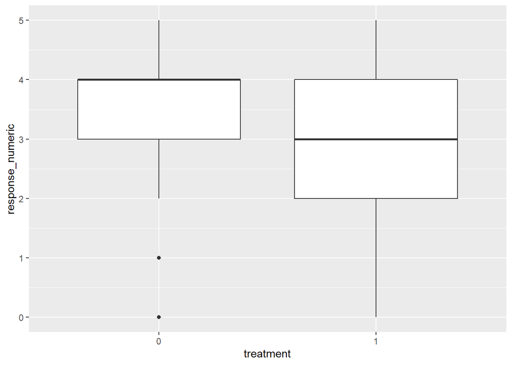

```r
surveyData %>%
  ggplot(aes(x = treatment, y = response_numeric)) +
  geom_boxplot()
```

```r
lm_1 <- lm(response_numeric ~ treatment, data = surveyData)
lm_2 <- lm(response_numeric ~ treatment + gender + age + income + monthExpense + profWorker +
             streamingService + phoneOS + noWifiHrs, data = surveyData)
```

To further identify the treatment effect of the presenting format on the willingness to pay. We perform a series of regressions using the data we collected as below.

The first column represents a simple OLS regression model of the treatment on the outcome variable. While the estimated constant term represents the average outcome level – the likelihood/willingness to pay for the premium plan, the coefficient of the treatment variable stands for the causal effect from the presenting format. We may infer that, on average, assuming the experiment is well randomized and all other factors controlled, the table format of presenting or comparing products may bring down the mean likelihood of purchasing by 0.414, measured in a 6-point continuous scale.

The second column is the OLS model, including all the control variables we collected from the participants. When controlling for more features between the two groups, we can still observe a significant gap between the likelihood of opting for the premium plan of the two groups.

We expect that the control variables distribute evenly between the two groups, and they should not demonstrate significant capability in explaining the variance in our outcome variable. But from the table, we can still observe that some coefficients are statistically significant, e.g. the dummy indicating more than $100,000 annual income, the dummy indicating monthly expense between $3,000 to $4,000, the dummy indicating the subscription of streaming service, and the dummy indicating the daily time without WIFI between 10 to 15 hours. The significance of these coefficients means that these attributes are not randomly assigned to the two groups. There are still some underlying differences between the treatment and control group to identify the true causal effect.

```r
stargazer(lm_1, lm_2,
          title = "OLS Regression",
          type = "text",
          model.numbers = FALSE,
          omit = c(),
          covariate.labels = c("Treatment", "Male", "Non-binary Gender",
                               "Undeclared Gender", "Age 25-29", "Age 30-39",
                               "Age 40+", "Income $25k-$50k", "Income $50k-$75k",
                               "Income $75k-$100k", "Income $100k+", "Expense $1k-$2k",
                               "Expense $2k-$3k", "Expense $3k-$4k", "Expense $4k+",
                               "Professional", "Streaming Service", "iOS", "No Wifi 3h-6h",
                               "No Wifi 6h-10h", "No Wifi 10h-15h", "No Wifi 15h+", "Constant")
)
```

```
##
## OLS Regression
## ===================================================================
##                                   Dependent variable:
##                     -----------------------------------------------
##                                    response_numeric
## -------------------------------------------------------------------
## Treatment                  -0.414***               -0.368***
##                             (0.114)                 (0.111)
##
## Male                                                 0.136
##                                                     (0.114)
##
## Non-binary Gender                                   -0.240
##                                                     (0.758)
##
## Undeclared Gender                                   -1.258*
##                                                     (0.661)
##
## Age 25-29                                            0.128
##                                                     (0.179)
##
## Age 30-39                                           -0.058
##                                                     (0.174)
##
## Age 40+                                             -0.016
##                                                     (0.181)
##
## Income 25k-50k                                       0.022
##                                                     (0.160)
##
## Income 50k-75k                                       0.051
##                                                     (0.187)
##
## Income 75k-100k                                     -0.093
##                                                     (0.234)
##
## Income 100k+                                        0.590**
##                                                     (0.279)
##
```

[output cut: 29 more lines]

```
##
## No Wifi 15h+                                         0.432
##                                                     (0.403)
##
## Constant                   3.362***                2.431***
##                             (0.081)                 (0.202)
##
## -------------------------------------------------------------------
## Observations                  565                     564
## R2                           0.023                   0.138
## Adjusted R2                  0.021                   0.103
## Residual Std. Error    1.354 (df = 563)        1.297 (df = 541)
## F Statistic         13.226*** (df = 1; 563) 3.931*** (df = 22; 541)
## ===================================================================
## Note:                                   *p<0.1; **p<0.05; ***p<0.01
```

The treatment effects identified from the regression above reveal that the table format of presenting products brings negative effects on the customers’ willingness to pay for the premium services, at least in our phone plan scenario, which is somewhat contradicting our original assumption that clearer comparison may nudge the customers to make a more premium choice. We guess that this phenomenon may be due to the following two reasons:

1. The table format helps customers to behave more rationally. The comparison table clearly lists the functional differences between the two services, enabling customers to compare price differences and feature differences between products more straightforwardly and quantitatively. The more complete the customer’s understanding of product information, the more impulsive consumption behavior may be offset by rationality.
2. The standard and premium plan design in our scenario is unreasonable. When most of the functions of the two plans and the pricing strategies are determined arbitrarily, we may probably come up with two plans with inductive bias that comes from the consumption habits of the designers. Although we believe that the two plans should be equally attractive to customers, one of them may be the one more favored by the real-world users. In our case, the standard plan may seem more cost-effective so that when the information of the two plans is revealed more thoroughly, more customers may turn to the standard one.

In the next section, we study the heterogeneous effects. How does the treatment effect differ for different types of respondents?

```r
he_gender <- lm(response_numeric ~ treatment + gender + treatment:gender,
                data = surveyData)

he_age <- lm(response_numeric ~ treatment + age + treatment:age,
                data = surveyData)

he_income <- lm(response_numeric ~ treatment + income + treatment:income,
                data = surveyData)

he_expense <- lm(response_numeric ~ treatment + monthExpense + treatment:monthExpense,
                data = surveyData)

he_prof <- lm(response_numeric ~ treatment + profWorker + treatment:profWorker,
                data = surveyData)

he_streaming <- lm(response_numeric ~ treatment + streamingService + treatment:streamingService,
                data = surveyData)

he_os <- lm(response_numeric ~ treatment + phoneOS + treatment:phoneOS,
                data = surveyData)

he_wifi <- lm(response_numeric ~ treatment + noWifiHrs + treatment:noWifiHrs,
                data = surveyData)
```

```r
stargazer(he_gender, he_age,
          title = "OLS Regression",
          type = "text",
          model.numbers = FALSE,
          covariate.labels = c("Treatment", "Male", "Non-binary Gender",
                               "Undeclared Gender", "Treatment:Male", "Treatment:Non-binary", "Treatment:Undeclared",
                               "Age 25-29", "Age 30-39", "Age 40+", "Treatment:Age 25-29",
                               "Treatment:Age 30-39", "Treatment:Age 40+", "Constant")
)
```

```
##
## OLS Regression
## ==================================================================
##                                   Dependent variable:
##                      ---------------------------------------------
##                                    response_numeric
## ------------------------------------------------------------------
## Treatment                  -0.679***               -0.427*
##                             (0.171)                (0.250)
##
## Male                         -0.006
##                             (0.164)
##
## Non-binary Gender           -2.381*
##                             (1.346)
##
## Undeclared Gender            -0.881
##                             (0.956)
##
## Treatment:Male              0.501**
##                             (0.229)
##
## Treatment:Non-binary         2.679
##                             (1.651)
##
## Treatment:Undeclared         -0.821
##                             (1.351)
##
## Age 25-29                                           0.274
##                                                    (0.252)
##
## Age 30-39                                           0.376
##                                                    (0.231)
##
## Age 40+                                             0.185
##                                                    (0.245)
##
## Treatment:Age 25-29                                 0.193
##                                                    (0.351)
##
## Treatment:Age 30-39                                 -0.214
##                                                    (0.318)
##
## Treatment:Age 40+                                   0.233
##                                                    (0.341)
##
## Constant                    3.381***               3.130***
##                             (0.126)                (0.184)
##
## ------------------------------------------------------------------
## Observations                  565                    564
## R2                           0.053                  0.036
## Adjusted R2                  0.041                  0.024
## Residual Std. Error     1.340 (df = 557)       1.353 (df = 556)
## F Statistic          4.471*** (df = 7; 557) 2.990*** (df = 7; 556)
## ==================================================================
## Note:                                  *p<0.1; **p<0.05; ***p<0.01
```

The treatment effect for males is less than that for females. On average, controlling for other factors, a table comparison of features is associated with 0.679 unit less likelihood of opting for the premium option for females, but only 0.178 unit less for males.

The treatment effect doesn’t vary by age group.

```r
stargazer(he_income, he_expense,
          title = "OLS Regression",
          type = "text",
          model.numbers = FALSE,
          covariate.labels = c("Treatment", "Income $25k-$50k", "Income $50k-$75k",
                               "Income $75k-$100k", "Income $100k+", "Treatment:Income $25k-$50k",
                               "Treatment:Income $50k-$75k", "Treatment:Income $75k-$100k", "Treatment:Income $100k+",
                               "Expense $1k-$2k", "Expense $2k-$3k", "Expense $3k-$4k", "Expense $4k+",
                               "Treatment:Expense $1k-$2k", "Treatment:Expense $2k-$3k",
                               "Treatment:Expense $3k-$4k", "Treatment:Expense $4k+", "Constant")
)
```

```
##
## OLS Regression
## ===========================================================
##                                    Dependent variable:
##                                ----------------------------
##                                      response_numeric
## -----------------------------------------------------------
## Treatment                         -0.425**      -0.591***
##                                   (0.205)        (0.199)
##
## Income 25k-50k                     0.297
##                                   (0.213)
##
## Income 50k-75k                    0.471**
##                                   (0.220)
##
## Income 75k-100k                    0.101
##                                   (0.295)
##
## Income 100k+                      0.835***
##                                   (0.317)
##
## Treatment:Income 25k-50k           -0.036
##                                   (0.294)
##
## Treatment:Income 50k-75k           -0.140
##                                   (0.310)
##
## Treatment:Income 75k-100k          0.634
##                                   (0.404)
##
## Treatment:Income 100k+             0.290
##                                   (0.467)
##
## Expense 1k-2k                                     0.248
##                                                  (0.193)
##
## Expense 2k-3k                                    0.494**
##                                                  (0.225)
##
```

[output cut: 14 more lines]

```
##
## Treatment:Expense 4k+                             0.041
##                                                  (0.600)
##
## Constant                          3.078***      3.102***
##                                   (0.152)        (0.141)
##
## -----------------------------------------------------------
## Observations                        565            565
## R2                                 0.064          0.082
## Adjusted R2                        0.049          0.067
## Residual Std. Error (df = 555)     1.335          1.322
## F Statistic (df = 9; 555)         4.223***      5.521***
## ===========================================================
## Note:                           *p<0.1; **p<0.05; ***p<0.01
```

The treatment effect doesn’t vary by income group or monthly expense group.

```r
stargazer(he_prof, he_streaming,
          title = "OLS Regression",
          type = "text",
          model.numbers = FALSE,
          covariate.labels = c("Treatment", "Professional", "Treatment:Professional",
                               "Streaming Service", "Treatment:Streaming Service",
                               "Constant")
)
```

```
##
## OLS Regression
## ===========================================================
##                                    Dependent variable:
##                                ----------------------------
##                                      response_numeric
## -----------------------------------------------------------
## Treatment                         -0.388*        -0.322
##                                   (0.206)        (0.229)
##
## Professional                      0.419**
##                                   (0.175)
##
## Treatment:Professional             -0.042
##                                   (0.247)
##
## Streaming Service                               0.633***
##                                                  (0.188)
##
## Treatment:Streaming Service                      -0.116
##                                                  (0.263)
##
## Constant                          3.071***      2.879***
##                                   (0.146)        (0.164)
##
## -----------------------------------------------------------
## Observations                        565            565
## R2                                 0.041          0.055
## Adjusted R2                        0.036          0.050
## Residual Std. Error (df = 561)     1.344          1.334
## F Statistic (df = 3; 561)         7.959***      10.971***
## ===========================================================
## Note:                           *p<0.1; **p<0.05; ***p<0.01
```

This table shows the heterogeneous effect of covariate ‘profworker’ (whether they are professional workers) and the heterogeneous effect of covariate ‘streamingService’ (Whether they have streaming service). We could find that the two heterogeneous effect are both not statistically significant, which indicates that the treatment affect sub-groups similarly, in other words, this heterogeneous effect is similar across different sub-groups.

```r
stargazer(he_os, he_wifi,
          title = "OLS Regression",
          type = "text",
          model.numbers = FALSE,
          covariate.labels = c("Treatment", "iOS", "Treatment:iOS", "No Wifi 3h-6h",
                               "No Wifi 6h-10h", "No Wifi 10h-15h", "No Wifi 15h+",
                               "Treatment:No Wifi 3h-6h", "Treatment:No Wifi 6h-10h",
                               "Treatment:No Wifi 10h-15h", "Treatment:No Wifi 15h+",
                               "Constant")
)
```

```
##
## OLS Regression
## =======================================================================
##                                        Dependent variable:
##                           ---------------------------------------------
##                                         response_numeric
## -----------------------------------------------------------------------
## Treatment                       -0.453***              -0.555***
##                                  (0.149)                (0.152)
##
## iOS                               -0.179
##                                  (0.169)
##
## Treatment:iOS                     0.122
##                                  (0.233)
##
## No Wifi 3h-6h                                            0.156
##                                                         (0.198)
##
## No Wifi 6h-10h                                           0.305
##                                                         (0.232)
##
## No Wifi 10h-15h                                          0.131
##                                                         (0.387)
##
## No Wifi 15h+                                             0.747
##                                                         (0.518)
##
## Treatment:No Wifi 3h-6h                                  0.370
##                                                         (0.278)
##
## Treatment:No Wifi 6h-10h                                 0.183
##                                                         (0.327)
##
## Treatment:No Wifi 10h-15h                               1.094**
##                                                         (0.547)
##
## Treatment:No Wifi 15h+                                   -0.945
##                                                         (0.853)
##
## Constant                         3.427***               3.253***
##                                  (0.102)                (0.109)
##
## -----------------------------------------------------------------------
## Observations                       565                    565
## R2                                0.025                  0.058
## Adjusted R2                       0.020                  0.043
## Residual Std. Error          1.355 (df = 561)       1.339 (df = 555)
## F Statistic               4.822*** (df = 3; 561) 3.798*** (df = 9; 555)
## =======================================================================
## Note:                                       *p<0.1; **p<0.05; ***p<0.01
```

This table shows the heterogeneous effect of covariate ‘phoneOS’ (cellphone operating system type) and the heterogeneous effect of covariate ‘noWifiHrs’ (the number of hours without wifi access). We could find that the heterogeneous effect of ‘phoneOS’ is not statistically significant, which indicates that the treatment affect sub-groups(people who use IOS, people who use Android) similarly. In other words, this heterogeneous effect is similar across different sub-groups of variable ‘phoneOS’.

However, the treatment effect for respondents who don’t have access to WIFI for 10-15 hours is less than that for respondents who don’t have access to WIFI for 0-3 hours. This makes sense, since people tend to buy premium (unlimited cellular data) when they have little access to WIFI.

## 5. Results

## 6. Conclusion